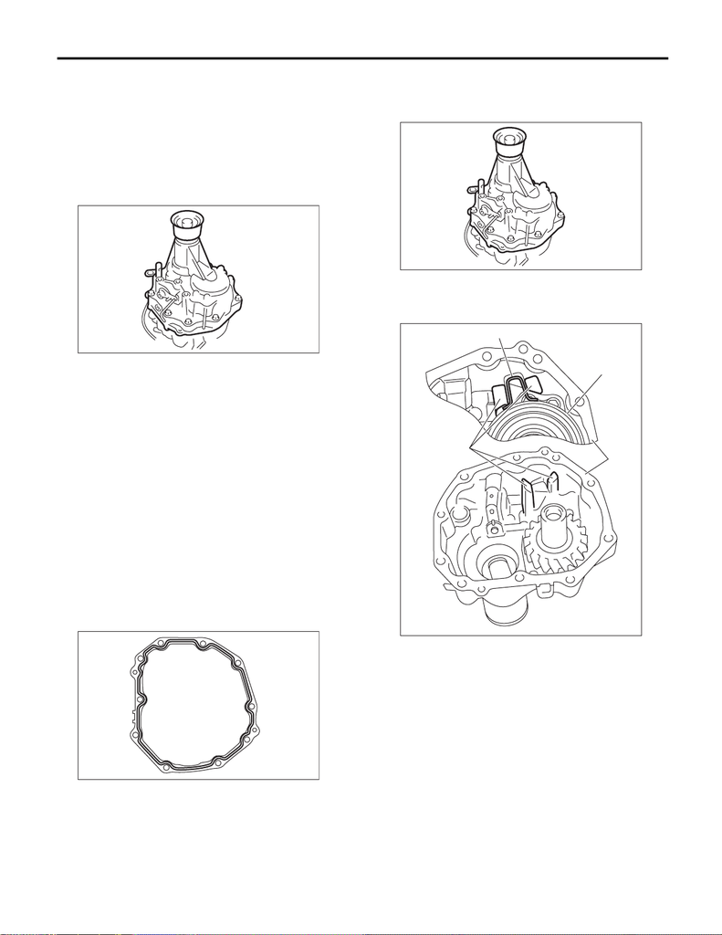

6MT(TY85)-42

Extension Case

MANUAL TRANSMISSION AND DIFFERENTIAL

13.Extension Case

A: REMOVAL

1) Remove the manual transmission assembly

from the vehicle. <Ref. to 6MT(TY85)-31, REMOV-

AL, Manual Transmission Assembly.>

2) Prepare the transmission for overhaul. <Ref. to

6MT(TY85)-38, Preparation for Overhaul.>

3) Remove the extension case.

4) Remove any remaining liquid gasket from the

extension case and transmission case.

B: INSTALLATION

1) Select the adjusting washer of the transfer driv-

en gear, and attach it to the extension case. <Ref.

to 6MT(TY85)-44, ADJUSTMENT, Extension

Case.>

2) Install the taper roller bearing (extension case

side) outer race to the extension case.

CAUTION:

Apply transmission gear oil onto sliding or re-

volving surfaces before installation.

3) Select the adjusting washer of the transfer drive

gear, and attach it to the center differential.

4) Apply liquid gasket to the transmission case.

Liquid gasket:

THREE BOND 1215B or equivalent

5) Install the extension case.

Tightening torque:

48 N·m (4.9 kgf-m, 35.4 ft-lb)

NOTE:

Insert the stopper section of the center differential

between the oil guide.

6) Install the manual transmission assembly to the

vehicle. <Ref. to 6MT(TY85)-33, INSTALLATION,

Manual Transmission Assembly.>

MT-00475

MT-00476

(A) Oil guide

(B) Stopper

(C) Center differential

(D) Extension case

MT-00475

MT-00973

(A)

(B)

(C)

(D)

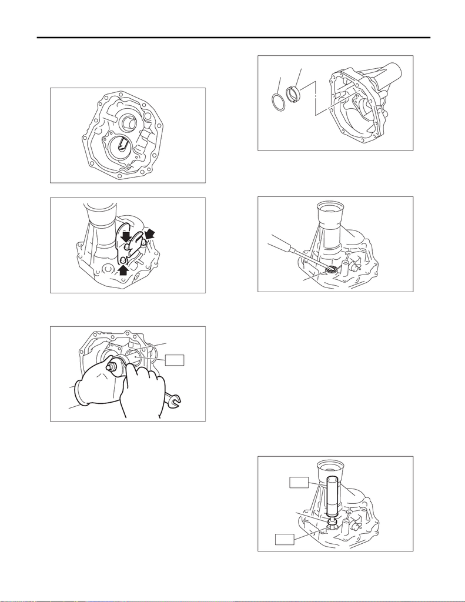

6MT(TY85)-43

Extension Case

MANUAL TRANSMISSION AND DIFFERENTIAL

C: DISASSEMBLY

1) Remove the transfer drive gear. <Ref. to

6MT(TY85)-52, REMOVAL, Transfer Drive Gear.>

2) Remove the oil guide.

3) Remove the shift bracket.

4) Using the ST, remove the taper roller bearing

(extension case side) outer race.

ST 18758AA000 PULLER

5) Remove the adjusting washer and oil plate.

6) Remove the shifter arm oil seal.

7) Remove the reverse check system. <Ref. to

6MT(TY85)-49, REMOVAL, Reverse Check Sys-

tem.>

8) Remove the extension oil seal. <Ref. to

6MT(TY85)-27, REPLACEMENT, Oil Seal.>

D: ASSEMBLY

1) Install the reverse check system. <Ref. to

6MT(TY85)-50, INSTALLATION, Reverse Check

System.>

2) Install the extension case oil seal. <Ref. to

6MT(TY85)-27, REPLACEMENT, Oil Seal.>

3) Using the ST, install the shifter arm shaft oil seal.

ST1 18657AA000 INSTALLER

ST2 18671AA000 OIL SEAL GUIDE

(A) Taper roller bearing (extension case side) outer

race

MT-00477

MT-00478

MT-00479

(A)

ST

(A) Adjusting washer

(B) Oil plate

(A) Oil seal

(A) Oil seal

MT-00480

(A)

(B)

MT-00481

(A)

MT-00482

(A)

ST1

ST2

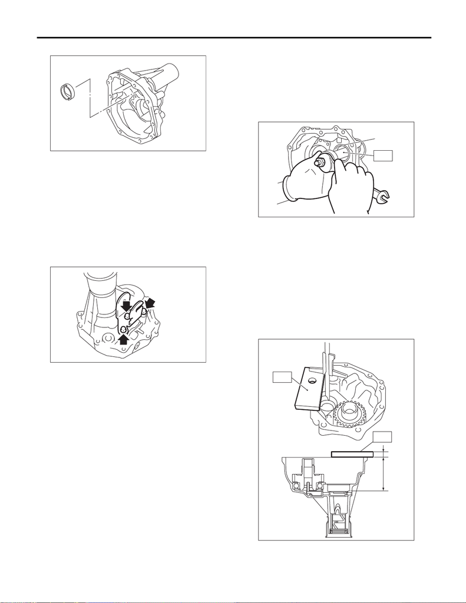

6MT(TY85)-44

Extension Case

MANUAL TRANSMISSION AND DIFFERENTIAL

4) Install the oil plate.

5) Select the adjusting washer of the bearing, and

attach it to the extension case. <Ref. to

6MT(TY85)-44, ADJUSTMENT, Extension Case.>

6) Install the taper roller bearing (extension case

side) outer race to the extension case.

CAUTION:

Apply transmission gear oil onto sliding or re-

volving surfaces before installation.

7) Install the shift bracket.

Tightening torque:

25 N·m (2.5 kgf-m, 18.4 ft-lb)

<Ref. to 6MT(TY85)-52, INSTALLATION, Transfer

Drive Gear.>

E: INSPECTION

1) Check to make sure there is no damage or

cracks on the extension case. If damage or crack-

ing is found, replace the extension case.

2) Inspect for oil leaks at the extension case and

transmission case oil seals and mating surfaces. If

there are oil leaks, replace the oil seal and liquid

gasket.

F: ADJUSTMENT

1. TRANSFER DRIVEN GEAR BEARING

ADJUSTING WASHER ADJUSTMENT

1) Using the ST, remove the taper roller bearing

(extension case side) outer race from the extension

case.

ST 18758AA000 PULLER

2) Remove the adjusting washer.

3) Measure depth “Z” between the extension case

end area and the taper roller bearing (extension

case side) contact area.

ST 398643600 GAUGE

NOTE:

When measuring depth “Z”, subtract the thickness

of the ST [15 mm (0.59 in)] from the measured val-

ue.

MT-00483

MT-00478

(A) Taper roller bearing (extension case side) outer

race

(A) 15 mm (0.59 in)

MT-00479

(A)

ST

MT-01420

(A)

Z

ST

ST

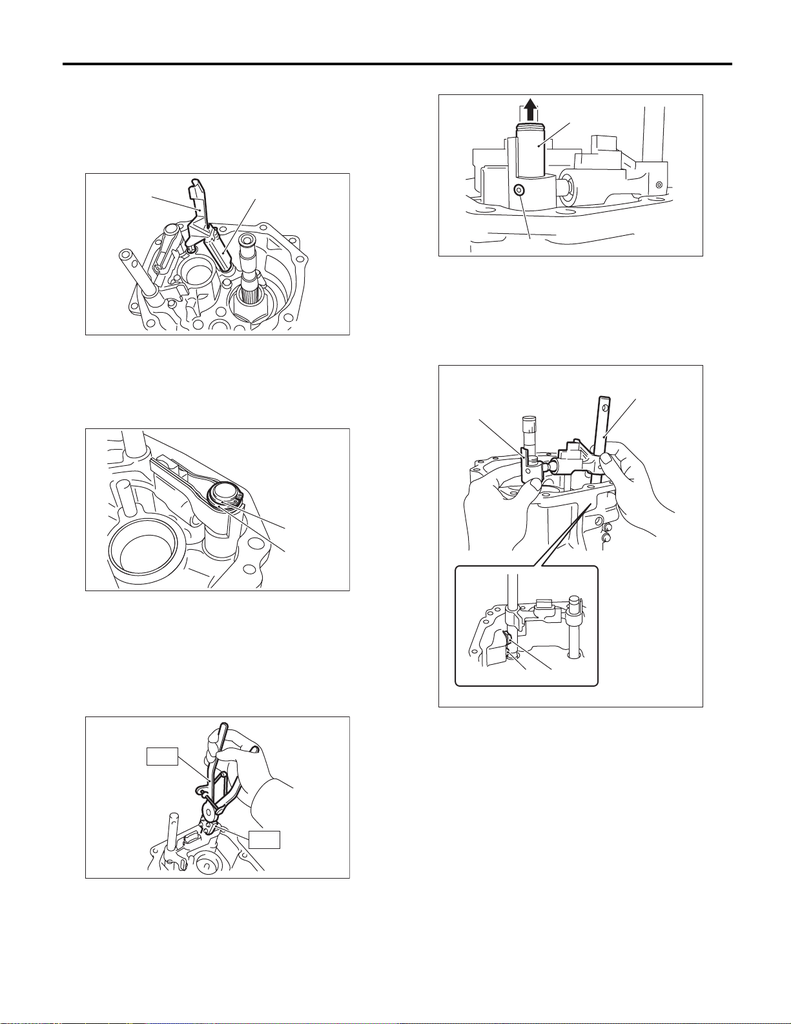

6MT(TY85)-45

Extension Case

MANUAL TRANSMISSION AND DIFFERENTIAL

4) Remove the transfer driven gear. <Ref. to

6MT(TY85)-54, REMOVAL, Transfer Driven

Gear.>

5) Remove the center differential. <Ref. to

6MT(TY85)-56, REMOVAL, Center Differential.>

6) Remove the oil guides G and H.

7) Remove the snap ring and flat washer from the

selector arm area.

8) Using an ST, remove the neutral set spring and

support.

ST1 18756AA000 CLAW

ST2 399893600 PLIER

9) Lift the striking rod, and remove the straight pin.

10) Remove the selector arm No. 2, shifter arm

shaft, selector plunger, shift accent plunger and

spring.

11) Attach the taper roller bearing (extension case

side) to the transfer driven gear.

(A) Oil guide G

(B) Oil guide H

(A) Snap ring

(B) Flat washer

MT-01728

(A)

(B)

MT-01616

(B)

(A)

MT-01092

ST2

ST1

(A) Striking rod

(B) Straight pin

(A) Selector arm No. 2

(B) Shifter arm shaft

(C) Selector plunger

(D) Shift accent plunger

MT-01307

(A)

(B)

MT-03101

(B)

(A)

(C)(D)

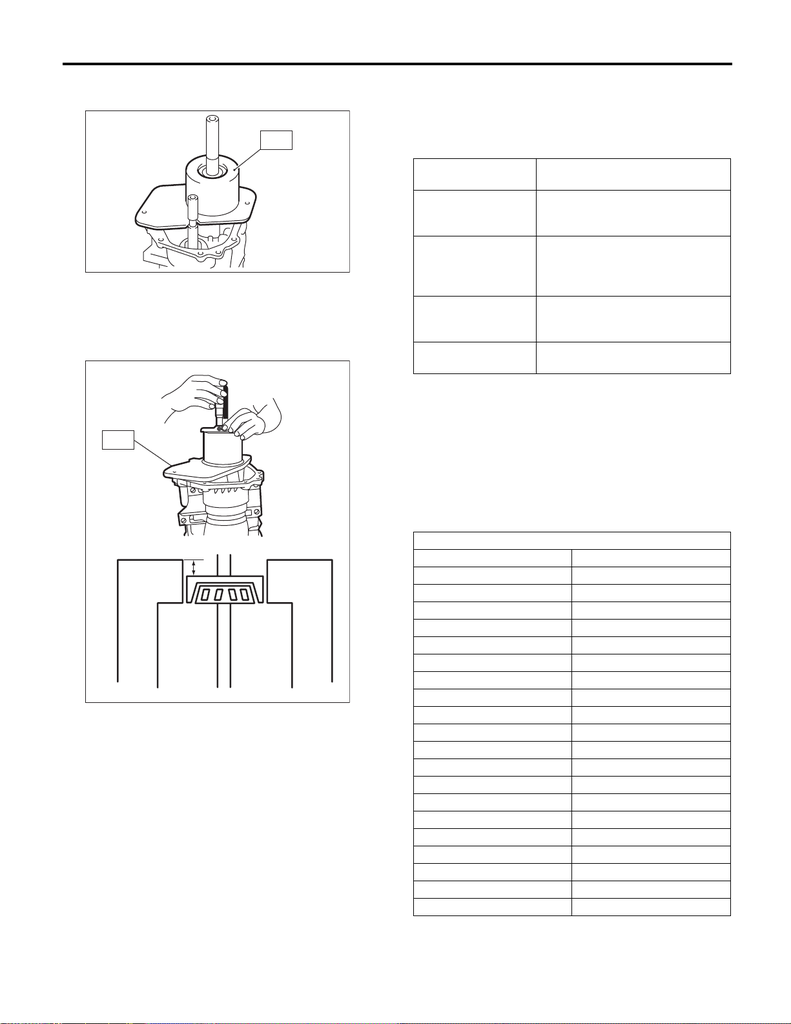

6MT(TY85)-46

Extension Case

MANUAL TRANSMISSION AND DIFFERENTIAL

12) Set the ST.

ST 18831AA000 GAUGE

13) Turn the transfer driven gear 10 or more times

to seat the bearing properly.

14) Measure depth “Y” between the end of the ST

and the taper roller bearing (extension case side).

ST 18831AA000 GAUGE

15) Using the following calculation, calculate the

transfer driven gear bearing adjusting washer value

“t”.

t = Z – (100 – Y) – {0.02 — 0.11 mm (0.0008 —

0.0043 in)}

16) Refer to the calculated value “t” to select the

closest adjusting washer from the following table.

Standard clearance between the adjusting

washer and the taper roller bearing (extension

case side)

0.02 — 0.11 mm (0.0008 — 0.0043 in)

NOTE:

Match to be within the standard clearance range.

MT-00489

ST

MT-00490

Y

ST

t

mm (in)

Transfer driven gear bearing adjust-

ing washer thickness

Y

mm (in)

Depth between the end of the ST

and the taper roller bearing (exten-

sion case side)

Z

mm (in)

Depth between the end of the

extension case and the taper roller

bearing (extension case side) con-

tact area

0.02 — 0.11 mm

(0.0008 — 0.0043 in)

Standard clearance between the

adjusting washer and the taper

roller bearing (extension case side)

100 mm

(3.94 in)

Height of ST

Adjusting washer (50 × 61 × t)

Part No. Thickness t mm (in)

803050060 0.50 (0.0197)

803050061 0.55 (0.0217)

803050062 0.60 (0.0236)

803050063 0.65 (0.0256)

803050064 0.70 (0.0276)

803050065 0.75 (0.0295)

803050066 0.80 (0.0315)

803050067 0.85 (0.0335)

803050068 0.90 (0.0354)

803050069 0.95 (0.0374)

803050070 1.00 (0.0394)

803050071 1.05 (0.0413)

803050072 1.10 (0.0433)

803050073 1.15 (0.0453)

803050074 1.20 (0.0472)

803050075 1.25 (0.0492)

803050076 1.30 (0.0512)

803050077 1.35 (0.0531)

803050078 1.40 (0.0551)

803050079 1.45 (0.0570)

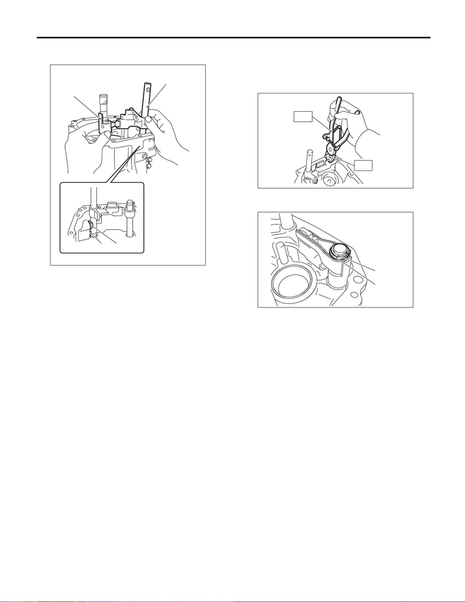

6MT(TY85)-47

Extension Case

MANUAL TRANSMISSION AND DIFFERENTIAL

17) Install the selector arm No. 2, shifter arm shaft,

selector plunger, shift accent plunger and spring.

18) Install a new straight pin.

19) Using the ST, install the neutral set spring and

support.

ST1 18756AA000 CLAW

ST2 399893600 PLIER

20) Install the flat washer and snap ring to the se-

lector arm area.

21) Install the center differential. <Ref. to

6MT(TY85)-56, INSTALLATION, Center Differen-

tial.>

(A) Selector arm No. 2

(B) Shifter arm shaft

(C) Selector plunger

(D) Shift accent plunger

MT-03101

(B)

(A)

(C)(D)

(A) Snap ring

(B) Flat washer

MT-01092

ST2

ST1

MT-01616

(B)

(A)

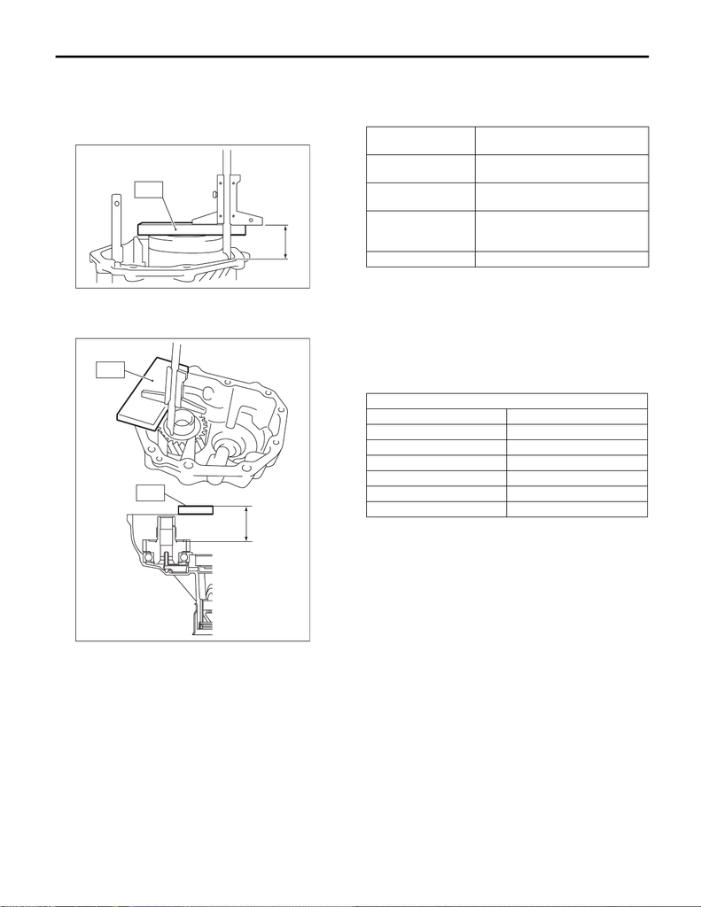

6MT(TY85)-48

Extension Case

MANUAL TRANSMISSION AND DIFFERENTIAL

2. TRANSFER DRIVE GEAR ADJUSTING

WASHER SELECTION

1) Measure height “Z” between the transmission

case end area and ST.

ST 398643600 GAUGE

2) Measure depth “Y” between the end of the ST

and the transfer drive gear.

ST 398643600 GAUGE

3) Using the following calculation, calculate the

transfer drive gear adjusting washer value “t”.

t = {Y – 15 mm (0.59 in)} – {Z – 15 mm (0.59 in)} –

0.75 — 0.95 mm (0.030 — 0.037 in)

4) Refer to the calculated value “t” to select the

closest adjusting washer from the following table.

Standard clearance between the adjusting

washer and transfer drive gear

0.75 — 0.95 mm (0.030 — 0.037 in)

NOTE:

Match to be within the standard clearance range.

5) Install the selected adjusting washer.

Z

ST

MT-00949

MT-01421

ST

ST

Y

t

mm (in)

Transfer drive gear adjusting washer

thickness

Y

mm (in)

Depth between the end of the ST

and the transfer drive gear

Z

mm (in)

Height from the end of the transmis-

sion case to the end of the ST.

0.75 — 0.95 mm

(0.030 — 0.037 in)

Standard clearance between the

adjusting washer and transfer drive

gear

15 mm (0.591 in) Thickness of ST

Adjusting washer (36.3 × 52 × t)

Part No. Thickness mm (in)

803036070 0.80 (0.0315)

803036071 0.95 (0.0374)

803036072 1.10 (0.0433)

803036073 1.25 (0.0492)

803036074 1.40 (0.0551)